# Analiza porównawcza za pomocą modeli GARCH

Michał Szłapa 397384 , Rafal Kaczmarek 396945

4 07 2021

## Wstęp

Głównym celem badania jest analiza ryzyka, które zdefiniowane będzie w formie funkcji warunkowej wariancji w modelach GARCH. W pracy zaimplementowane zostały następujące modele GARCH i EGARCH. Następnie analiza zostanie podzielona na próbkę in sample oraz out of sample. Na koniec na podstawie Value at Risk wybrany zostanie najlepszy spośród modeli.

Zbiór składa się z czterech kryptowalut: switcheo, komodo, metronome, ravencoin. Dane pochodzą z okresu od 01/01/2019 – 20/04/2021. Portfel obejmuje 841 obserwacji. Dane pochodzą z “https://www.coingecko.com/en/coins/” . Na początku zostanie policzony udział procentowy każdej z kryptowalut w portfelu a następnie obliczona zostanie wspólna stopa zwrotu.

### 1.Pozyskanie danych oraz analiza

Na początku wgrane zostaną niezbędne biblioteki ora zdefiniowana zostanie funkcja za pomocą, której pozyskamy niezbędne do analizy dane.

```r
library(lmtest)
library(xts)
library(urca)
library(fBasics)
library(dygraphs)
library(tseries)
library(car)
library(rugarch)
library(fGarch)
library(timeSeries)
library(MTS)
library(fBasics) # e.g. basicStats()
library(tseries)# e.g. jarque.bera.test()
library(lmtest) # e.g. dwtest()
library(car) # e.g. dwtest()
library(MTS) # e.g. archTest()
library(fGarch) # e.g. garchFit()
library(rugarch)
library(MTS)
library(rlist)
library(stats)
library(kableExtra)

getdata = function(crypto='', start_date='2011-01-01', end_date='2021-04-21'){
  library('rvest')
  webpage = read_html(paste0("https://www.coingecko.com/en/coins/",crypto,
                             "/historical_data/usd?start_date=", start_date,"&end_date=",end_date,"#panel"))
  tbls = html_nodes(webpage, "tr")
  table = tbls %>% html_text()
  rows = gsub(',,',',',gsub(' ','',gsub('.{1}$','\n',gsub('\n',',',gsub('\n\n',',',gsub('\n\n\n',',',
                                                                                        gsub('\\$','',gsub(',', '' ,table))))))))
  to_df = paste(rows, collapse = '')
  df = read.csv(text=to_df)
  df = df[-1,]
  df$Close = as.numeric(df$Close)
  return (df)
}

switcheo=getdata(crypto = 'switcheo')
komodo = getdata(crypto = 'komodo')
metronome = getdata(crypto = 'metronome')
ravencoin = getdata(crypto = 'ravencoin')

switcheo$Date <- as.Date(switcheo$Date, format = "%Y-%m-%d")
komodo$Date <- as.Date(komodo $Date, format = "%Y-%m-%d")
metronome$Date <- as.Date(metronome$Date, format = "%Y-%m-%d")
ravencoin$Date <- as.Date(ravencoin$Date, format = "%Y-%m-%d")
```

Podstawowe statystyki opisowe

```r
summary(switcheo)
```

```
##       Date              MarketCap             Volume             Open
##  Min.   :2018-04-04   Min.   :        0   Min.   :      2   Min.   :0.001805
##  1st Qu.:2019-01-16   1st Qu.:  2433642   1st Qu.:   5925   1st Qu.:0.003550
##  Median :2019-10-18   Median :  3542248   Median :  22619   Median :0.005182
##  Mean   :2019-10-17   Mean   : 12677992   Mean   : 208232   Mean   :0.015613
##  3rd Qu.:2020-07-19   3rd Qu.: 16829250   3rd Qu.: 243513   3rd Qu.:0.024112
##  Max.   :2021-04-20   Max.   :139918343   Max.   :6797600   Max.   :0.099490
##      Close
##  Min.   :0.001805
##  1st Qu.:0.003550
##  Median :0.005182
##  Mean   :0.015674
##  3rd Qu.:0.024253
##  Max.   :0.099490
```

```r
summary(komodo)
```

```
##       Date              MarketCap             Volume
##  Min.   :2017-02-05   Min.   :0.000e+00   Min.   :      564
##  1st Qu.:2018-02-24   1st Qu.:7.022e+07   1st Qu.:   908644
##  Median :2019-03-15   Median :1.026e+08   Median :  2434081
##  Mean   :2019-03-14   Mean   :1.550e+08   Mean   :  4498631
##  3rd Qu.:2020-04-01   3rd Qu.:1.721e+08   3rd Qu.:  4426894
##  Max.   :2021-04-20   Max.   :1.198e+09   Max.   :202897487
##       Open              Close
##  Min.   : 0.03708   Min.   : 0.03708
##  1st Qu.: 0.59008   1st Qu.: 0.59023
##  Median : 0.91811   Median : 0.91817
##  Mean   : 1.42666   Mean   : 1.42837
##  3rd Qu.: 1.58000   3rd Qu.: 1.58000
##  Max.   :11.54000   Max.   :11.54000
```

```r
summary(metronome)
```

```
##       Date              MarketCap            Volume             Open
##  Min.   :2018-06-28   Min.   :       0   Min.   :   1399   Min.   :0.2296
##  1st Qu.:2019-03-21   1st Qu.: 5637200   1st Qu.:  95456   1st Qu.:0.5683
##  Median :2019-11-30   Median : 8575962   Median : 259317   Median :0.8650
##  Mean   :2019-11-29   Mean   :10488620   Mean   : 339458   Mean   :1.0559
##  3rd Qu.:2020-08-09   3rd Qu.:12279072   3rd Qu.: 462283   3rd Qu.:1.3400
##  Max.   :2021-04-20   Max.   :44185505   Max.   :4172164   Max.   :4.4000
##      Close
##  Min.   :0.2296
##  1st Qu.:0.5683
##  Median :0.8650
##  Mean   :1.0570
##  3rd Qu.:1.3400
##  Max.   :4.4000
```

```r
summary(ravencoin)
```

```
##       Date              MarketCap             Volume               Open
##  Min.   :2018-03-21   Min.   :0.000e+00   Min.   :6.536e+04   Min.   :0.01012
##  1st Qu.:2018-12-27   1st Qu.:5.342e+07   1st Qu.:3.681e+06   1st Qu.:0.01627
##  Median :2019-10-05   Median :1.194e+08   Median :1.256e+07   Median :0.02309
##  Mean   :2019-10-05   Mean   :1.978e+08   Mean   :4.316e+07   Mean   :0.03582
##  3rd Qu.:2020-07-12   3rd Qu.:1.572e+08   3rd Qu.:2.560e+07   3rd Qu.:0.03773
##  Max.   :2021-04-20   Max.   :1.991e+09   Max.   :3.689e+09   Max.   :0.23457
##      Close
##  Min.   :0.01012
##  1st Qu.:0.01627
##  Median :0.02309
##  Mean   :0.03596
##  3rd Qu.:0.03777
##  Max.   :0.23457
```

Dalsze przekształcenia danych

```r
#Pozodtawiamy tylko istotne kolumny
switcheo <- switcheo[, c("Date","MarketCap" ,"Close")]
komodo <- komodo[, c("Date","MarketCap" ,"Close")]
metronome <- metronome[, c("Date","MarketCap" ,"Close")]
ravencoin <- ravencoin[, c("Date","MarketCap" ,"Close")]

#Zmiana nazw
colnames(switcheo) <- c("Date","switcheo_cap" ,"switcheo_close")
colnames(komodo) <- c("Date","komodo_cap" ,"komodo_close")
colnames(metronome) <- c("Date","metronome_cap" ,"metronome_close")
colnames(ravencoin) <- c("Date","ravencoin_cap" ,"ravencoin_close")

switcheo <- switcheo[switcheo$Date >= "2019-01-01",]
komodo <- komodo[komodo$Date >= "2019-01-01",]
metronome <- metronome[metronome$Date >= "2019-01-01",]
ravencoin <- ravencoin[ravencoin$Date >= "2019-01-01",]


# łączenie tabel
data = merge(switcheo, komodo, by.x = "Date", by.y = "Date")
data = merge(data, metronome, by.x = "Date", by.y = "Date")
data = merge(data, ravencoin, by.x = "Date", by.y = "Date")
```

### 2. Budowa portfela

```r
data$total_cap = as.numeric(data$switcheo_cap) + as.numeric(data$komodo_cap) + as.numeric(data$metronome_cap) + as.numeric(data$ravencoin_cap)



data$metronome_cap=as.numeric(data$metronome_cap)

data$switcheo_p = (data$switcheo_cap/data$total_cap)
data$komodo_p = (data$komodo_cap/data$total_cap)
data$metronome_p = (as.numeric(data$metronome_cap)/data$total_cap)
data$ravencoin_p = (data$ravencoin_cap/data$total_cap)


data$switcheo_r = diff.xts(log(data$switcheo_close))
data$komodo_r = diff.xts(log(data$komodo_close))
data$metronome_r = diff.xts(log(data$metronome_close))
data$ravencoin_r = diff.xts(log(data$ravencoin_close))


data$r_t = (data$switcheo_p*data$switcheo_r
                +data$komodo_p*data$komodo_r
                +data$metronome_p*data$metronome_r
                +data$ravencoin_p*data$ravencoin_r)

data$r_t = (data$switcheo_p*data$switcheo_r
                +data$komodo_p*data$komodo_r
                +data$metronome_p*data$metronome_r
                +data$ravencoin_p*data$ravencoin_r)
```

Procentowy udział kryptowalut w całym portfelu

```r
udzial = xts(data[, c("switcheo_p", "komodo_p", "metronome_p", "ravencoin_p")], order.by = data$Date)
dygraph(udzial, main = "Udzial kryptowalut w portfelu") %>%
  dyRangeSelector(height = 50)
```

[interactive chart not shown]

Wykres cen zamknięcia

```r
cena_zamkn = xts(data[, c("switcheo_close", "komodo_close", "metronome_close", "ravencoin_close")], order.by = data$Date)
stopa_zwrotu = xts(data[, c("r_t")], order.by = data$Date)

dygraph(cena_zamkn, main = 'Ceny zamknięcia dla kryptowalut') %>%
  dyRangeSelector(height = 50)
```

[interactive chart not shown]

Wykres stóp zwrotów dla całego portfela

```r
dygraph(stopa_zwrotu, main = "Stopy zwrotów dla całego portfela") %>%
  dyRangeSelector(height = 50)
```

[interactive chart not shown]

### 3.Analiza rozkładu zmiennej stopy zwrotów z całego portfela

Pierwszy wykres to histogram zmiennej, do której dodano dodatkowo linie gestosci rozkladu normalnego. Rozkład szeregu wygląda na leptokurtyczny. Dodatkowo wykres Q-Q (Quantile-Quantile) potwierdza, że raczej nie mamy tu do czynienia z rozkładem normalnym. Obserwacje sa częściej oddalone od średniej niż w rozkładzie normalnym

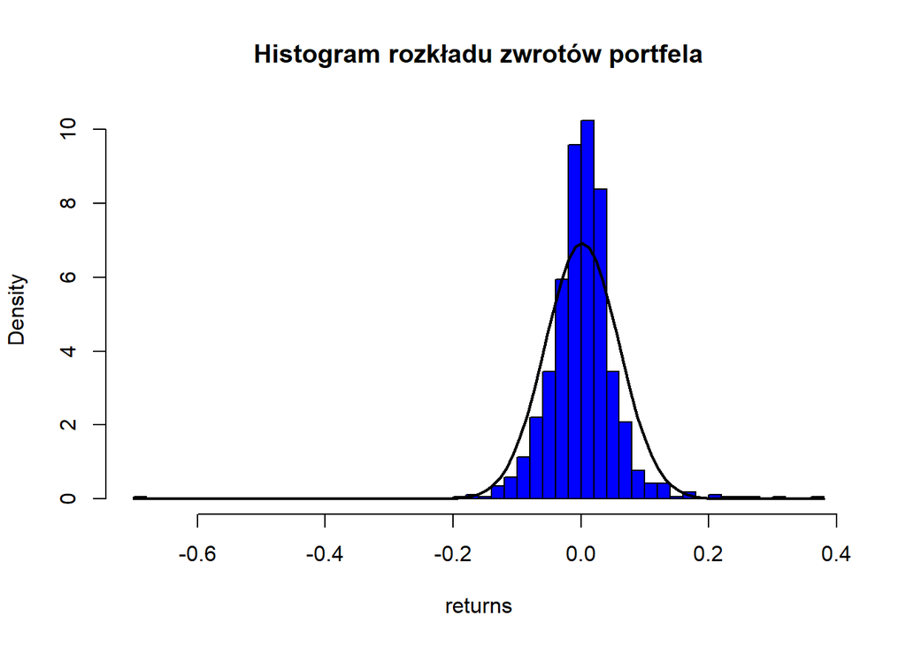

```r
hist(data$r_t, prob = T, breaks = 50, main = "Histogram rozkładu zwrotów portfela", xlab="returns", col="blue")
curve(dnorm(x, mean = mean(data$r_t, na.rm = T),
            sd  = sd(data$r_t, na.rm = T)),
      col = "black", lwd = 2, add = TRUE,
)
```

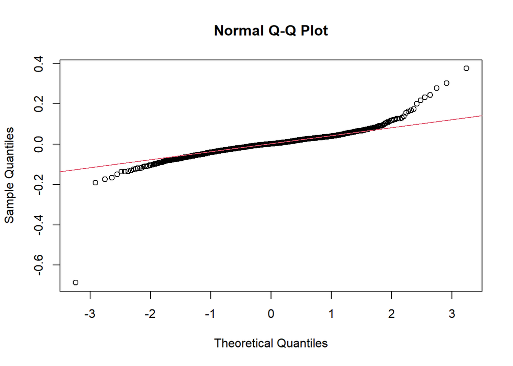

```r
qqnorm(data$r_t)
qqline(data$r_t, col = 2)
```

Test Jarque Bera rownież potwierdza brak rozkładu normalnego

```r
jbtest <- jarque.bera.test(na.omit(data$r_t)) # brak stopy zwrotu przy pierwszej obserwacji
jbtest
```

```
##
##  Jarque Bera Test
##
## data:  na.omit(data$r_t)
## X-squared = 28091, df = 2, p-value < 2.2e-16
```

### 4. Analiza autokorelacji

Na podstawie wykresów ACF dla zwrotów i kwadratóW zwrotów możemy wywnioskować występowanie autokorelacji

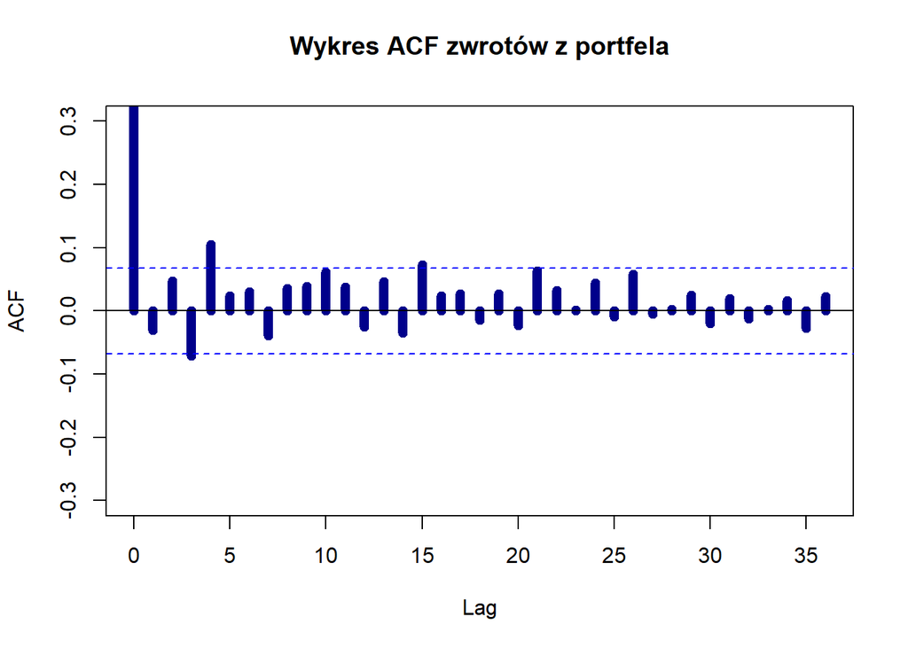

```r
acf(data$r_t, lag.max = 36, na.action = na.pass,
    ylim = c(-0.3, 0.3),
    col = "darkblue", lwd = 7,
    main = "Wykres ACF zwrotów z portfela")
```

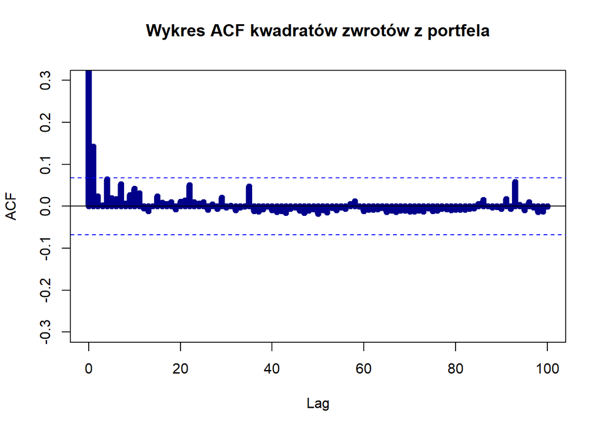

```r
acf(data$r_t^2, lag.max = 100, na.action = na.pass,
    ylim = c(-0.3, 0.3),
    col = "darkblue", lwd = 7,
    main = "Wykres ACF kwadratów zwrotów z portfela")
```

Dla zwrotów i kwadratów zwrotów odrzucono H0 o braku autokorelacji

```r
Box.test(data$r_t, lag = 5, type = 'Ljung-Box')
```

```
##
##  Box-Ljung test
##
## data:  data$r_t
## X-squared = 16.933, df = 5, p-value = 0.004628
```

```r
Box.test(data$r_t^2, lag = 5, type = 'Ljung-Box')
```

```
##
##  Box-Ljung test
##
## data:  data$r_t^2
## X-squared = 21.266, df = 5, p-value = 0.0007213
```

Dla 5 pierwszych opoznien: odrzucamy hipotezę o braku autokorelacji dla 3 i 4 opóźnienia. w przypadku kwadratów zwrotów odrzucamy hipotezę o braku autokorelacji tylko dla 1 opóźnienia

```r
durbinWatsonTest(lm(formula = data$r_t ~ 1),
                 max.lag = 5)
```

```
##  lag Autocorrelation D-W Statistic p-value
##    1     -0.03087476      2.061705   0.356
##    2      0.04779933      1.901734   0.154
##    3     -0.07149202      2.135767   0.042
##    4      0.10533410      1.781040   0.014
##    5      0.02418708      1.940696   0.436
##  Alternative hypothesis: rho[lag] != 0
```

```r
durbinWatsonTest(lm(formula = data$r_t ^ 2 ~ 1),
                 max.lag = 5)
```

```
##  lag Autocorrelation D-W Statistic p-value
##    1     0.142009943      1.715903   0.020
##    2     0.023911830      1.952099   0.176
##    3     0.002194763      1.995234   0.578
##    4     0.063894886      1.871798   0.078
##    5     0.019591584      1.960329   0.266
##  Alternative hypothesis: rho[lag] != 0
```

Odrzucamy H0 o nieistotności efektów ARCH

```r
archTest(na.omit(data$r_t), lag = 5)
```

```
## Q(m) of squared series(LM test):
## Test statistic:  21.26644  p-value:  0.0007213343
## Rank-based Test:
## Test statistic:  43.78944  p-value:  2.555739e-08
```

Wynik wstępnej analizy jest następujący: obecnosc autokorelacji dla logatymicznych stop zwrotu pozwala na estymowanie wartosci oczekiwanych stóp zwrotu na podstawie ich przeszłych wartosc. Stąd wniosek o mozżiwosci zastosowania modelów GARCH.

## 5.Modele GARCH oraz EGARCH

W tym rozdziale skupiono się na przeprowadzeniu odpowiedniego wnioskowania dotyczącego wybrania najlepszego modelu GARCH oraz EGARCH. Jednakże, zanim rozpoczęto czynności związane z wyborem odpowiedniego modelu, to ze zbioru danych wyselekcjonowano próbę “in sample” oraz “out of sample”.

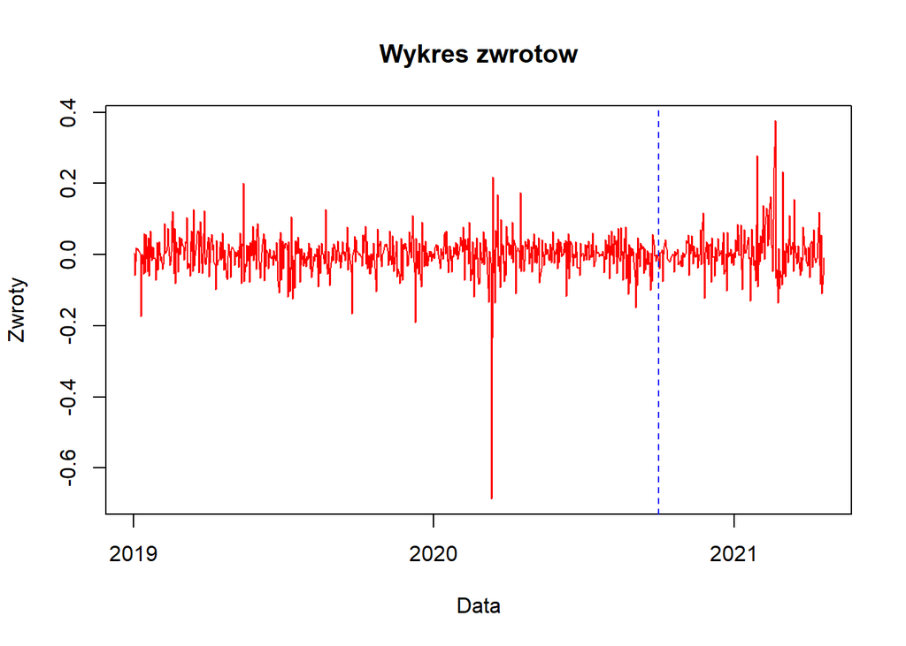

```r
# in sample
proba_in = data[which((data$Date < "2020-10-01" & data$Date > "2019-01-01")),]

# out of sample
proba_out = data[which(data$Date >= "2020-10-01"),]

# wykres
plot(data$Date, data$r_t, type = "l", lwd = 1, col = "red", main = "Wykres zwrotow",
     xlab = "Data", ylab = "Zwroty")
abline(v=as.Date("2020-10-01"),col=c("blue"), lty=c(2))
```

Wykres przedstawia jak kształtują się zwroty w czasie. Niebieska linia przedstawia datę, która rozdziela zbiór danych na próbę “in sample” oraz “out of sample”.

### Model GARCH

W tym podrozdziale przedstawiono działania mające na celu wybranie najlepszego modelu GARCH. Przetestowano kilka wariantów:

- GARCH(1,1),
- GARCH(2,1),
- GARCH(2,2),
- MA(1)-GARCH(1,1),
- MA(1)-GARCH(2,1),
- MA(1)-GARCH(2,2).

Na początku zweryfikowano modele z mu != 0, ale w każdym z nich był problem z istotnością parametrów dlatego w przedstawionych modelach założono, że mu=0.

```r
#GARCH(1,1)
spec <- ugarchspec(variance.model = list(model = "sGARCH",
                                         garchOrder = c(1, 1)),
                   mean.model = list(armaOrder = c(0, 0),
                                     include.mean = F),
                   distribution.model = "norm")

proba_in.garch11 <- ugarchfit(spec = spec,
                         data = na.omit(proba_in$r_t))



#GARCH(2,1)
spec <- ugarchspec(variance.model = list(model = "sGARCH",
                                         garchOrder = c(2, 1)),
                   mean.model = list(armaOrder = c(0, 0),
                                     include.mean = F),
                   distribution.model = "norm")

proba_in.garch21 <- ugarchfit(spec = spec,
                         data = na.omit(proba_in$r_t))


#GARCH(2,2)
spec <- ugarchspec(variance.model = list(model = "sGARCH",
                                         garchOrder = c(2, 2)),
                   mean.model = list(armaOrder = c(0, 0),
                                     include.mean = F),
                   distribution.model = "norm")

proba_in.garch22 <- ugarchfit(spec = spec,
                         data = na.omit(proba_in$r_t))


#MA(1)-GARCH(1,1)

spec <- ugarchspec(variance.model = list(model = "sGARCH",
                                         garchOrder = c(1, 1)),
                   mean.model = list(armaOrder = c(0, 1),
                                     include.mean = F),
                   distribution.model = "norm")

proba_in.ma1_garch11 <- ugarchfit(spec = spec,
                         data = na.omit(proba_in$r_t))



#MA(1)-GARCH(2,1)

spec <- ugarchspec(variance.model = list(model = "sGARCH",
                                         garchOrder = c(2, 1)),
                   mean.model = list(armaOrder = c(0, 1),
                                     include.mean = F),
                   distribution.model = "norm")

proba_in.ma1_garch21 <- ugarchfit(spec = spec,
                                data = na.omit(proba_in$r_t))

#MA(1)-GARCH(2,2)

spec <- ugarchspec(variance.model = list(model = "sGARCH",
                                         garchOrder = c(2, 2)),
                   mean.model = list(armaOrder = c(0, 1),
                                     include.mean = F),
                   distribution.model = "norm")

proba_in.ma1_garch22 <- ugarchfit(spec = spec,
                                data = na.omit(proba_in$r_t))


##### Porownanie

GARCH_models = rbind(c( -3.0466 ,-3.0256    ,-3.0466    ,-3.0385    ),  c(  -3.0593 ,-3.0314    ,-3.0594    ,-3.0485    ),
                     c( -3.0562 ,-3.0213    ,-3.0563    ,-3.0426    ),  c(  -3.0490 ,-3.0211    ,-3.0491    ,-3.0382    ),
                     c( -3.0642 ,-3.0293    ,-3.0643    ,-3.0507    ),  c(  -3.0948 ,-3.0529    ,-3.0950    ,-3.0785    ))

colnames(GARCH_models) <- c("Akaike", "Bayes", "Shibata", "Hannan-Quinn")
rownames(GARCH_models) <- c( "GARCH(1,1)", "GARCH(2,1)", "GARCH(2,2)","MA(1)-GARCH(1,1)",
                             "MA(1)-GARCH(2,1)","MA(1)-GARCH(2,2)")
```

|  | Akaike | Bayes | Shibata | Hannan-Quinn |
| --- | --- | --- | --- | --- |
| GARCH(1,1) | -3.0466 | -3.0256 | -3.0466 | -3.0385 |
| GARCH(2,1) | -3.0593 | -3.0314 | -3.0594 | -3.0485 |
| GARCH(2,2) | -3.0562 | -3.0213 | -3.0563 | -3.0426 |
| MA(1)-GARCH(1,1) | -3.0490 | -3.0211 | -3.0491 | -3.0382 |
| MA(1)-GARCH(2,1) | -3.0642 | -3.0293 | -3.0643 | -3.0507 |
| MA(1)-GARCH(2,2) | -3.0948 | -3.0529 | -3.0950 | -3.0785 |

Kryteria informacyjne są bardzo zbliżone dla każdego z modeli, aczkolwiek tylko w modelu GARCH(1,1) wszystkie parametry okazały się istotne (na poziomie istotności 5%) co wpłynęło na wybór tego modelu. W modelu MA(1)-GARCH(1,1) występował tylko jeden nieistotny parametr, który dodatkowo był bliski poziomu istotności (p-value= 0.06), ale kryteria informacyjne dla tego modelu były bardzo zbliżone do kryteriów informacyjnych dla modelu GARCH(1,1) co rozwiało wątpliwości o wyborze odpowiedniego modelu. Poniżej przedstawiony jest wydruk dla modelu GARCH(1,1).

```r
proba_in.garch11
```

```
##
## *---------------------------------*
## *          GARCH Model Fit        *
## *---------------------------------*
##
## Conditional Variance Dynamics
## -----------------------------------
## GARCH Model  : sGARCH(1,1)
## Mean Model   : ARFIMA(0,0,0)
## Distribution : norm
##
## Optimal Parameters
## ------------------------------------
##         Estimate  Std. Error  t value Pr(>|t|)
## omega   0.000215    0.000085   2.5254 0.011556
## alpha1  0.165620    0.048677   3.4024 0.000668
## beta1   0.800766    0.043621  18.3574 0.000000
##
## Robust Standard Errors:
##         Estimate  Std. Error  t value Pr(>|t|)
## omega   0.000215    0.000213   1.0098  0.31259
## alpha1  0.165620    0.144071   1.1496  0.25032
## beta1   0.800766    0.066165  12.1026  0.00000
##
## LogLikelihood : 974.8648
##
## Information Criteria
## ------------------------------------
##
## Akaike       -3.0466
## Bayes        -3.0256
## Shibata      -3.0466
## Hannan-Quinn -3.0385
##
## Weighted Ljung-Box Test on Standardized Residuals
## ------------------------------------
##                         statistic p-value
## Lag[1]                     0.6546  0.4185
## Lag[2*(p+q)+(p+q)-1][2]    0.6910  0.6103
## Lag[4*(p+q)+(p+q)-1][5]    1.8678  0.6500
```

[output cut: 34 more lines]

```
## Negative Sign Bias  0.5347 0.5930
## Positive Sign Bias  0.2220 0.8244
## Joint Effect        1.6198 0.6549
##
##
## Adjusted Pearson Goodness-of-Fit Test:
## ------------------------------------
##   group statistic p-value(g-1)
## 1    20     80.75    1.383e-09
## 2    30     87.08    1.018e-07
## 3    40    105.70    4.592e-08
## 4    50    114.98    3.184e-07
##
##
## Elapsed time : 0.05714607
```

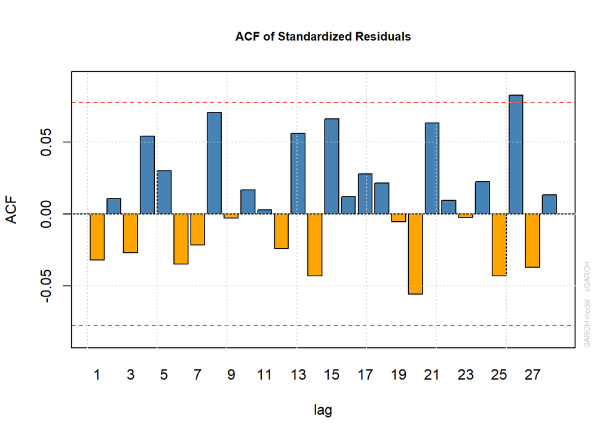

```r
plot(proba_in.garch11, which = 10)
```

Na podstawie powyżej zaprezentowanych wyników dla wybranego modelu GARCH(1,1) można zauważyć, ze efekty ARCH i MA zostały wyeliminowane co zostało wywnioskowane na podstawie testów Ljunga-Boxa i Arch LM. Wyniki testu nie w pełni pokrywają się z wykresem. Jedna z wypustek może być kwestią sporna, ponieważ przekracza ona nieznacznie linie obszaru krytycznego, ale wynik testu przedstawionego powyżej rozwiewa wątpliwości co do słuszności rozumowania na podstawie wykresu co oznacza, że autokorelacja reszt nie występuje.

### Model EGARCH

Parametry do modelów EGARCH został dobrane dokładnie takie same jak w przypadku modeli GARCH. Podobnie jak z modelami GARCH, na początku zweryfikowano dokładnie te same modele z mu!=0, ale w każdym z nich był problem z istotnością zmiennych dlatego przyjęto mu=0.

```r
#EGARCH(1,1)
spec <- ugarchspec(variance.model = list(model = "eGARCH",
                                         garchOrder = c(1, 1)),
                   mean.model = list(armaOrder = c(0, 0),
                                     include.mean = F),
                   distribution.model = "norm")

proba_in.egarch11 <- ugarchfit(spec = spec,
                          data = na.omit(proba_in$r_t))


#EGARCH(2,1)
spec <- ugarchspec(variance.model = list(model = "eGARCH",
                                         garchOrder = c(2, 1)),
                   mean.model = list(armaOrder = c(0, 0),
                                     include.mean = F),
                   distribution.model = "norm")

proba_in.egarch21 <- ugarchfit(spec = spec,
                          data = na.omit(proba_in$r_t))


#EGARCH(2,2)
spec <- ugarchspec(variance.model = list(model = "eGARCH",
                                         garchOrder = c(2, 2)),
                   mean.model = list(armaOrder = c(0, 0),
                                     include.mean = F),
                   distribution.model = "norm")

proba_in.egarch22 <- ugarchfit(spec = spec,
                          data = na.omit(proba_in$r_t))


#MA(1)-EGARCH(1,1)

spec <- ugarchspec(variance.model = list(model = "eGARCH",
                                         garchOrder = c(1, 1)),
                   mean.model = list(armaOrder = c(0, 1),
                                     include.mean = F),
                   distribution.model = "norm")

proba_in.ma1_egarch11 <- ugarchfit(spec = spec,
                              data = na.omit(proba_in$r_t))


#MA(1)-EGARCH(2,1)

spec <- ugarchspec(variance.model = list(model = "eGARCH",
                                         garchOrder = c(2, 1)),
                   mean.model = list(armaOrder = c(0, 1),
                                     include.mean = F),
                   distribution.model = "norm")

proba_in.ma1_egarch21 <- ugarchfit(spec = spec,
                              data = na.omit(proba_in$r_t))

#MA(1)-EGARCH(2,2)

spec <- ugarchspec(variance.model = list(model = "eGARCH",
                                         garchOrder = c(2, 2)),
                   mean.model = list(armaOrder = c(0, 1),
                                     include.mean = F),
                   distribution.model = "norm")

proba_in.ma1_egarch22 <- ugarchfit(spec = spec,
                              data = na.omit(proba_in$r_t))


##### Porownanie

EGARCH_models = rbind(c(    -3.0697 ,-3.0418    ,-3.0698    ,-3.0589    ),  c(  -3.0661 ,-3.0242    ,-3.0663    ,-3.0498    ),
                      c(    -3.0807 ,-3.0317    ,-3.0809    ,-3.0617    ),  c(  -3.0709 ,-3.0360    ,-3.0711    ,-3.0574    ),
                      c(    -3.0683 ,-3.0194    ,-3.0685    ,-3.0493    ),  c(  -3.0814 ,-3.0255    ,-3.0818    ,-3.0597    ))


colnames(EGARCH_models) <- c("Akaike", "Bayes", "Shibata", "Hannan-Quinn")
rownames(EGARCH_models) <- c("EGARCH(1,1)", "EGARCH(2,1)", "EGARCH(2,2)",
                             "MA(1)-EGARCH(1,1)","MA(1)-EGARCH(2,1)","MA(1)-EGARCH(2,2)")
```

|  | Akaike | Bayes | Shibata | Hannan-Quinn |
| --- | --- | --- | --- | --- |
| EGARCH(1,1) | -3.0697 | -3.0418 | -3.0698 | -3.0589 |
| EGARCH(2,1) | -3.0661 | -3.0242 | -3.0663 | -3.0498 |
| EGARCH(2,2) | -3.0807 | -3.0317 | -3.0809 | -3.0617 |
| MA(1)-EGARCH(1,1) | -3.0709 | -3.0360 | -3.0711 | -3.0574 |
| MA(1)-EGARCH(2,1) | -3.0683 | -3.0194 | -3.0685 | -3.0493 |
| MA(1)-EGARCH(2,2) | -3.0814 | -3.0255 | -3.0818 | -3.0597 |

W przypadku modeli EGARCH to modele EGARCH(1,1) oraz MA(1)-EGARCH(1,1) charakteryzują się wszystkimi zmiennymi istotnymi. Różnice kryteriów informacyjnych miedzy tymi modelami są niewielkie oraz trudno jest stwierdzić na podstawie kryteriów informacyjnych który model jest lepszy, więc wybrano model mniej skomplikowany - EGARCH(1,1)

```r
proba_in.egarch11
```

```
##
## *---------------------------------*
## *          GARCH Model Fit        *
## *---------------------------------*
##
## Conditional Variance Dynamics
## -----------------------------------
## GARCH Model  : eGARCH(1,1)
## Mean Model   : ARFIMA(0,0,0)
## Distribution : norm
##
## Optimal Parameters
## ------------------------------------
##         Estimate  Std. Error  t value Pr(>|t|)
## omega  -0.325766    0.063972  -5.0923 0.000000
## alpha1 -0.089481    0.012467  -7.1775 0.000000
## beta1   0.942947    0.010665  88.4132 0.000000
## gamma1  0.117851    0.034001   3.4661 0.000528
##
## Robust Standard Errors:
##         Estimate  Std. Error  t value Pr(>|t|)
## omega  -0.325766    0.104986  -3.1030 0.001916
## alpha1 -0.089481    0.061006  -1.4668 0.142443
## beta1   0.942947    0.015025  62.7586 0.000000
## gamma1  0.117851    0.043520   2.7080 0.006769
##
## LogLikelihood : 983.2501
##
## Information Criteria
## ------------------------------------
##
## Akaike       -3.0697
## Bayes        -3.0418
## Shibata      -3.0698
## Hannan-Quinn -3.0589
##
## Weighted Ljung-Box Test on Standardized Residuals
## ------------------------------------
##                         statistic p-value
## Lag[1]                      2.784 0.09522
```

[output cut: 37 more lines]

```
## Negative Sign Bias  0.3741 0.7085
## Positive Sign Bias  0.2430 0.8081
## Joint Effect        1.0239 0.7955
##
##
## Adjusted Pearson Goodness-of-Fit Test:
## ------------------------------------
##   group statistic p-value(g-1)
## 1    20     64.70    6.841e-07
## 2    30     68.83    4.371e-05
## 3    40     84.76    3.099e-05
## 4    50     82.85    1.792e-03
##
##
## Elapsed time : 0.07180786
```

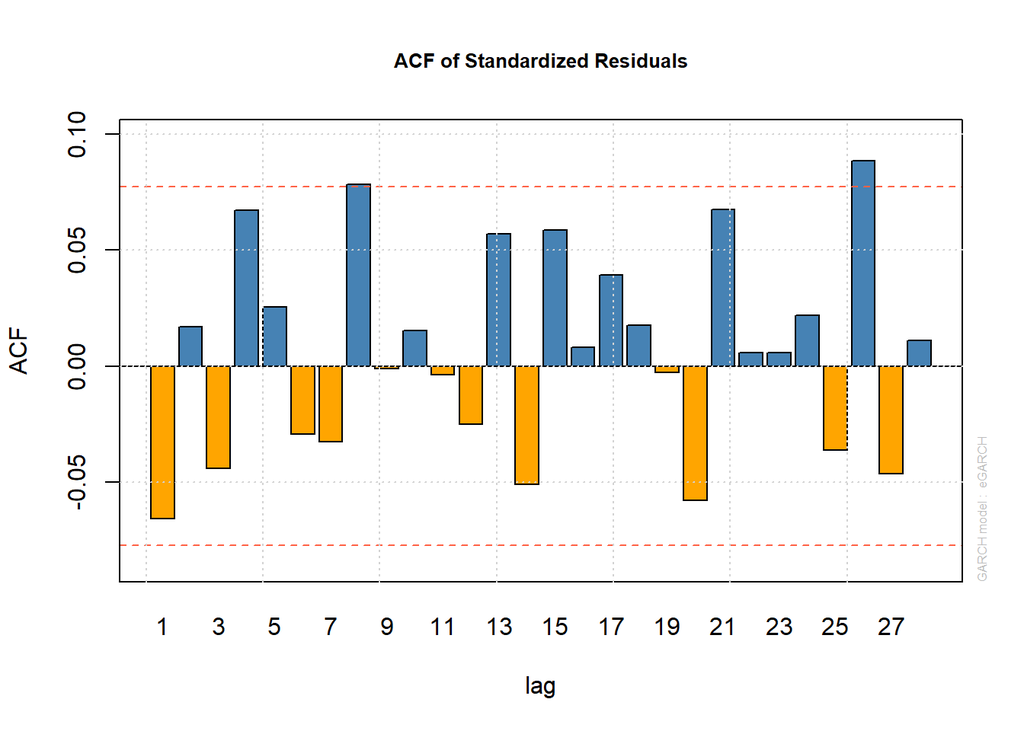

```r
plot(proba_in.egarch11, which = 10)
```

Na powyższym wydruku, można zauważyć ze w teście Ljunga-Boxa dla kwadratów wystandaryzowanych reszt występuje brak podstaw do odrzucenia hipotezy, że kwadraty wystandaryzowanych reszt są białym szumem. Dodatkowo z testu LM ARCH wywnioskowano brak występowania efektów ARCH wśród reszt modelu.

## Szacowanie wartości narażonej na ryzyko (VaR)

Na początek 1-dniowa prognoza warunkowego odchylenia standardowego

```r
proba_in$r_t_std <- (proba_in$r_t - mean(proba_in$r_t, na.rm=T)) /
  sd(proba_in$r_t, na.rm = T)

basicStats(proba_in$r_t_std)
```

```
##             X..proba_in.r_t_std
## nobs                 638.000000
## NAs                    0.000000
## Minimum              -12.677012
## Maximum                4.042456
## 1. Quartile           -0.444786
## 3. Quartile            0.548137
## Mean                   0.000000
## Median                 0.049342
## Sum                    0.000000
## SE Mean                0.039590
## LCL Mean              -0.077743
## UCL Mean               0.077743
## Variance               1.000000
## Stdev                  1.000000
## Skewness              -3.168457
## Kurtosis              40.447871
```

```r
r_t_std_q01 <- quantile(proba_in$r_t_std, 0.01, na.rm = T)
r_t_std_q01
```

```
##        1%
## -2.402994
```

```r
proba_in$VaR <-r_t_std_q01 * (proba_in.garch11@fit$sigma)


sigma.forecast_garch11 <- ugarchforecast(proba_in.garch11, n.ahead = 1)

sigma.forecast2_garch11 <- sigma.forecast_garch11@forecast$sigmaFor[1, 1]

forecast_garch11 <-ugarchforecast(proba_in.garch11, n.ahead = 1)
forecast2_garch11 <- forecast_garch11@forecast$sigmaFor[1,1]
VaR_garch11 <- r_t_std_q01*sigma.forecast2_garch11
```

Oszacowanie dla całego okresu “out of sample” na podstawie GARCH(1,1)

```r
data$obs = 1:length(data$r_t)

start   <- data$obs[data$Date == as.Date("2020-10-01")]
finish  <- data$obs[data$Date == as.Date("2021-04-20")]
data2 <- data[start:finish, ]
VaR_garch <- rep(NA, times = finish - start + 1)

mu <- rep(NA, times = finish - start + 1)
omega <- rep(NA, times = finish - start + 1)
alpha1 <- rep(NA, times = finish - start + 1)
beta1 <- rep(NA, times = finish - start + 1)


time1 <- Sys.time()
for (k in start:finish) {
  tmp.data <- data[data$obs <= (k - 1), ]
  tmp.data <- tmp.data[as.Date("2019-01-03") <= tmp.data$Date, ]
  tmp.data$rstd <- (tmp.data$r_t-mean(tmp.data$r_t, na.rm = T))/sd(tmp.data$r_t, na.rm = T)
  q01 <- quantile(tmp.data$rstd, 0.01, na.rm = T)
  spec <- ugarchspec(variance.model = list(model = "sGARCH",
                                           garchOrder = c(1, 1)),
                     mean.model = list(armaOrder = c(0, 0),
                                       include.mean = F),
                     distribution.model = "norm")
  tmp.garch11 <- ugarchfit(spec = spec, data = na.omit(tmp.data$r_t))
  sigma.forecast  <- ugarchforecast(tmp.garch11, n.ahead = 1)
  sigma.forecast2 <- sigma.forecast@forecast$sigmaFor[1, 1]
  VaR_garch[k - start + 1] <- q01 * sigma.forecast2
  mu[k - start + 1] <- tmp.garch11@fit$coef[1]
  omega[k - start + 1] <- tmp.garch11@fit$coef[2]
  alpha1[k - start + 1] <- tmp.garch11@fit$coef[3]
  beta1[k - start + 1] <- tmp.garch11@fit$coef[4]
}

data2$VaR_garch <- VaR_garch
```

Oszacowanie dla całego okresu “out of sample” na podstawie EGARCH(1,1)

```r
#EGARCH

proba_in$VaR <-r_t_std_q01 * (proba_in.egarch11@fit$sigma)


sigma.forecast_egarch11 <- ugarchforecast(proba_in.egarch11, n.ahead = 1)

sigma.forecast2_egarch11 <- sigma.forecast_egarch11@forecast$sigmaFor[1, 1]

forecast_egarch11 <-ugarchforecast(proba_in.egarch11, n.ahead = 1)
forecast2_egarch11 <- forecast_egarch11@forecast$sigmaFor[1,1]
VaR_egarch11 <- r_t_std_q01*sigma.forecast2_egarch11


VaR_egarch <- rep(NA, times = finish - start + 1)

mu <- rep(NA, times = finish - start + 1)
omega <- rep(NA, times = finish - start + 1)
alpha1 <- rep(NA, times = finish - start + 1)
beta1 <- rep(NA, times = finish - start + 1)


time1 <- Sys.time()
for (k in start:finish) {
  tmp.data <- data[data$obs <= (k - 1), ]
  tmp.data <- tmp.data[as.Date("2019-01-03") <= tmp.data$Date, ]
  tmp.data$rstd <- (tmp.data$r_t-mean(tmp.data$r_t, na.rm = T))/sd(tmp.data$r_t, na.rm = T)
  q01 <- quantile(tmp.data$rstd, 0.01, na.rm = T)
  spec <- ugarchspec(variance.model = list(model = "eGARCH",
                                           garchOrder = c(1, 1)),
                     mean.model = list(armaOrder = c(0, 0),
                                       include.mean = F),
                     distribution.model = "norm")
  tmp.egarch11 <- ugarchfit(spec = spec, data = na.omit(tmp.data$r_t))
  sigma.forecast  <- ugarchforecast(tmp.egarch11, n.ahead = 1)
  sigma.forecast2 <- sigma.forecast@forecast$sigmaFor[1, 1]
  VaR_egarch[k - start + 1] <- q01 * sigma.forecast2
  mu[k - start + 1] <- tmp.egarch11@fit$coef[1]
  omega[k - start + 1] <- tmp.egarch11@fit$coef[2]
  alpha1[k - start + 1] <- tmp.egarch11@fit$coef[3]
  beta1[k - start + 1] <- tmp.egarch11@fit$coef[4]
}

data2$VaR_egarch <- VaR_egarch
```

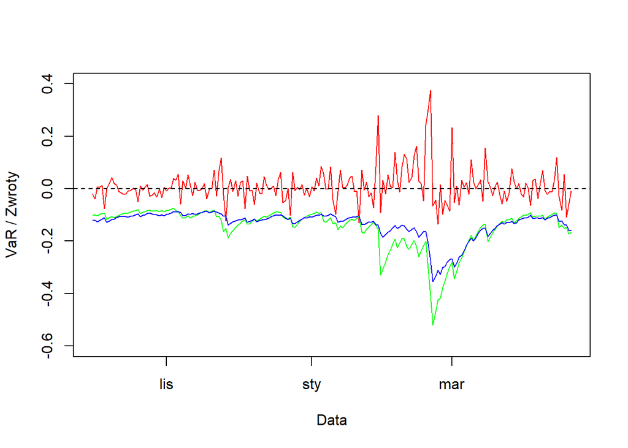

```r
plot(data2$Date, data2$r_t, col = "red", lwd = 1, type = 'l', xlab="Data",
     ylab="VaR / Zwroty", ylim = c(-0.6, 0.4))
abline(h = 0, lty = 2)
lines(data2$Date, data2$VaR_garch, type = 'l', col = "green")
lines(data2$Date, data2$VaR_egarch, type = 'l', col = "blue")
```

```r
#GARCH
sum(data2$r_t < data2$VaR_garch) / length(data2$VaR_garch)
```

```
## [1] 0.004950495
```

```r
#EGARCH
sum(data2$r_t < data2$VaR_egarch) / length(data2$VaR_egarch)
```

```
## [1] 0.00990099
```

Dla modelu GARCH(1,1) zakładany poziom wartości narażonej na ryzyko został przekroczony w 0.00495 przypadków, a dla modelu EGARCH(1,1) w 0.0099 przypadków, co oznacza,że w modelu GARCH(1,1) rzadziej przekraczany jest poziom wartości narażonej na ryzyko.

## Analiza wrażliwości

Na wykresach przedstawionych w poprzednich rozdziałach zauważono, ze w okolicy początku lutego zaczynają się znaczne fluktuacje. W związku z tym ograniczono próbę o 3 miesiące, od 01.10.2020 do 20.01.2021. Tak znaczne fluktuacje mogą być spowodowane pandemią koronawirusa, dlatego tym bardziej zasadne jest ograniczenie próby do okresu, w którym następstwa pandemii koronawirusa nie były tak znaczące.

```r
data$obs = 1:length(data$r_t)

start   <- data$obs[data$Date == as.Date("2020-10-01")]
finish  <- data$obs[data$Date == as.Date("2021-01-20")]
data2w <- data[start:finish, ]
VaR_garch <- rep(NA, times = finish - start + 1)

mu <- rep(NA, times = finish - start + 1)
omega <- rep(NA, times = finish - start + 1)
alpha1 <- rep(NA, times = finish - start + 1)
beta1 <- rep(NA, times = finish - start + 1)

time1 <- Sys.time()
for (k in start:finish) {
  tmp.data <- data[data$obs <= (k - 1), ]
  tmp.data <- tmp.data[as.Date("2019-01-03") <= tmp.data$Date, ]
  tmp.data$rstd <- (tmp.data$r_t-mean(tmp.data$r_t, na.rm = T))/sd(tmp.data$r_t, na.rm = T)
  q01 <- quantile(tmp.data$rstd, 0.01, na.rm = T)
  spec <- ugarchspec(variance.model = list(model = "sGARCH",
                                           garchOrder = c(1, 1)),
                     mean.model = list(armaOrder = c(0, 0),
                                       include.mean = F),
                     distribution.model = "norm")
  tmp.garch11 <- ugarchfit(spec = spec, data = na.omit(tmp.data$r_t))
  sigma.forecast  <- ugarchforecast(tmp.garch11, n.ahead = 1)
  sigma.forecast2 <- sigma.forecast@forecast$sigmaFor[1, 1]
  VaR_garch[k - start + 1] <- q01 * sigma.forecast2
  mu[k - start + 1] <- tmp.garch11@fit$coef[1]
  omega[k - start + 1] <- tmp.garch11@fit$coef[2]
  alpha1[k - start + 1] <- tmp.garch11@fit$coef[3]
  beta1[k - start + 1] <- tmp.garch11@fit$coef[4]
}

data2w$VaR_garch <- VaR_garch


#EGARCH

VaR_egarch <- rep(NA, times = finish - start + 1)

mu <- rep(NA, times = finish - start + 1)
omega <- rep(NA, times = finish - start + 1)
alpha1 <- rep(NA, times = finish - start + 1)
beta1 <- rep(NA, times = finish - start + 1)

time1 <- Sys.time()
for (k in start:finish) {
  tmp.data <- data[data$obs <= (k - 1), ]
  tmp.data <- tmp.data[as.Date("2019-01-03") <= tmp.data$Date, ]
  tmp.data$rstd <- (tmp.data$r_t-mean(tmp.data$r_t, na.rm = T))/sd(tmp.data$r_t, na.rm = T)
  q01 <- quantile(tmp.data$rstd, 0.01, na.rm = T)
  spec <- ugarchspec(variance.model = list(model = "eGARCH",
                                           garchOrder = c(1, 1)),
                     mean.model = list(armaOrder = c(0, 0),
                                       include.mean = F),
                     distribution.model = "norm")
  tmp.egarch11 <- ugarchfit(spec = spec, data = na.omit(tmp.data$r_t))
  sigma.forecast  <- ugarchforecast(tmp.egarch11, n.ahead = 1)
  sigma.forecast2 <- sigma.forecast@forecast$sigmaFor[1, 1]
  VaR_egarch[k - start + 1] <- q01 * sigma.forecast2
  mu[k - start + 1] <- tmp.egarch11@fit$coef[1]
  omega[k - start + 1] <- tmp.egarch11@fit$coef[2]
  alpha1[k - start + 1] <- tmp.egarch11@fit$coef[3]
  beta1[k - start + 1] <- tmp.egarch11@fit$coef[4]
}

data2w$VaR_egarch <- VaR_egarch
```

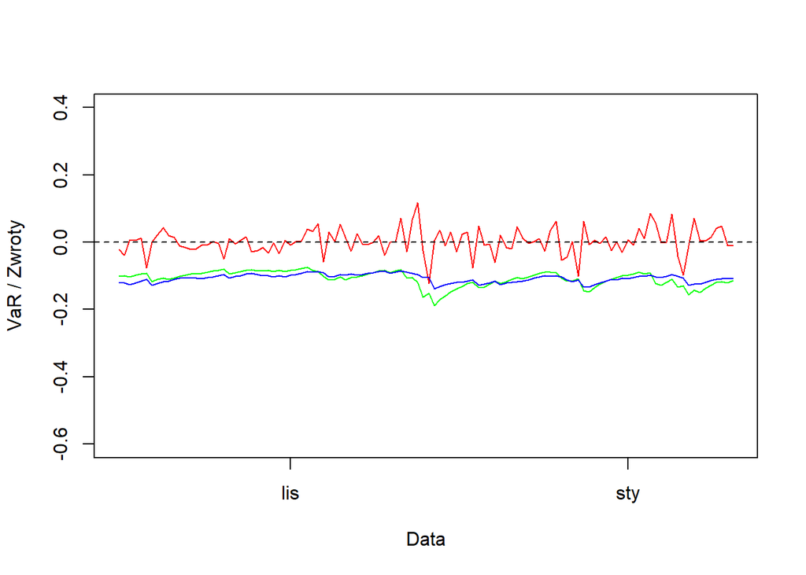

```r
plot(data2w$Date, data2w$r_t, col = "red", lwd = 1, type = 'l',xlab="Data",
     ylab="VaR / Zwroty", ylim = c(-0.6, 0.4))
abline(h = 0, lty = 2)
lines(data2w$Date, data2w$VaR_garch, type = 'l', col = "green")
lines(data2w$Date, data2w$VaR_egarch, type = 'l', col = "blue")
```

```r
#GARCH
sum(data2w$r_t < data2w$VaR_garch) / length(data2w$VaR_garch)
```

```
## [1] 0
```

```r
#EGARCH
sum(data2w$r_t < data2w$VaR_egarch) / length(data2w$VaR_egarch)
```

```
## [1] 0.008928571
```

## 6.Podsumowanie

W pracy wykorzystano modele GARCH w następujących formach: GARCH(1,1), GARCH(2,1), GARCH(2,2), MA(1)-GARCH(1,1), MA(1)-GARCH(2,1), MA(1)-GARCH(2,2). W wyniku analizy okazało się, że jedynie model GARCH(1,1) ma wszystkie parametry istotne oraz autokorelacja reszt nie występuje, a efekty ARCH i MA zostały wyeliminowane co zostało wywnioskowane na podstawie testów Ljunga-Boxa i Arch LM. Kryteria informacyjne dla wszystkich opisanych modeli miały bardzo zbliżone wartości. Następnie przeprowadzono weryfikację modeli EGARCH z identycznymi parametrami co w przypadku modeli GARCH. Podczas weryfikacji okazało się, że model EGARCH(1,1) oraz MA(1)-EGARCH(1,1) charakteryzują się wszystkimi zmiennymi istotnymi. Różnice kryteriów informacyjnych miedzy tymi modelami były niewielkie więc wybrano model mniej skomplikowany - EGARCH(1,1). Wyniki testów były identyczne co w przypadku modelu GARCH(1,1). Następnym krokiem było oszacowanie VaR. Dla modelu GARCH wyniosło ono 0.00495, a dla modelu EGARCH wyniosło 0.0099. Ostatnim etapem niniejszej pracy była analiza wrażliwości, w której próbę out of sample ograniczono o 3 miesiące, w których widoczny był znaczny wpływ pandemii koronawirusa. W tym przypadku VaR dla modelu GARCH było równe 0, a dla modelu EGARCH 0.00892. Oznacza to, że dla modelu GARCH poziom wartości narażonej na ryzyko nie jest przekraczany.